# Sex differences in blood pressure polygenic risk scores

**Libraries**

```r
packrat::on()
library(tidyverse)
library(survival)   # survival analysis
library(data.table) # fread() function
library(gridExtra)  # plots to grid
library(survminer)  # ggbased visualization and extra diagnostics
library(survRM2)    # restricted mean survival times
library(visdat)     # visualization of tibble and na's
library(forestplot) # forestplot
library(kableExtra) # pretty tables

#install.packages("kableExtra_1.2.1.tar.gz", repos=NULL, type="source")
#install.packages("webshot_0.5.2.tar.gz", repos=NULL, type="source")
#install.packages("knitr_1.29.tar.gz", repos=NULL, type="source")

source('/finngen/red/ht_prs/sex/Functions.R')

setwd("/home/ivm/red/ht_prs/sex")
```

# 1 Data

**Risk scores**

Calculated from UK Biobank (UKB) for Finngen Data Freeze 5 individuals using the PRS-CS18 pipeline with default parameters.

**Endpoints**

- I9_HYPTENS: Hypertension

**Copying and preprocessing data**

Endpoint and covariate files transfered and unzipped. Columns selected from endpoint file prior to import to r. There was not enough memory to upload full files to R.

```bash
#Endpoint file and covariate file copied and unzipped

cp /finngen/library-red/finngen_R5/phenotype_2.0/data/finngen_R5_V2_endpoint.gz /finngen/red/ht_prs/data/
cp /finngen/library-red/finngen_R5/phenotype_2.0/data/R5_cov_pheno_1.0.txt.gz /finngen/red/ht_prs/data/

gzip -d /finngen/red/ht_prs/data/finngen_R5_V2_endpoint.gz
gzip -d /finngen/red/ht_prs/data/R5_cov_pheno_1.0.txt.gz

#Self written perl-script to extract columns from phenotype file
perl select_columns.pl data/finngen_R5_V2_endpoint data/finngen_R5_V2_HT FINNGENID I9_HYPTENS I9_HYPTENS_AGE FU_END_AGE

#This could be loaded directly to R, but now loading will be faster...
perl select_columns.pl data/R5_cov_pheno_1.0.txt data/R5_cov_pheno_selected FINNGENID batch BL_YEAR cohort SEX_IMPUTED PC1 PC2 PC3 PC4 PC5 PC6 PC7 PC8 PC9 PC10
```

**Loading data**

```r
endpoints <- fread("/finngen/red/ht_prs/data/finngen_R5_V2_HT", sep = "\t")

sbp_prs_f <- fread("/finngen/red/test/ukb-sbp-female.profile") %>%
  select(IID, SCORE) %>%
  rename(SBP_F_SCORE=SCORE)

sbp_prs_m <- fread("/finngen/red/test/ukb-sbp-male.profile") %>%
  select(IID, SCORE) %>%
  rename(SBP_M_SCORE=SCORE)

covs <- fread("/finngen/red/ht_prs/data/R5_cov_pheno_selected")
```

**Combining data**

```r
df <- endpoints %>%
  left_join(sbp_prs_f, by = c("FINNGENID" = "IID")) %>%
  left_join(sbp_prs_m, by = c("FINNGENID" = "IID")) %>%
  left_join(covs, by = c("FINNGENID" = "FINNGENID"))

#Removing cases without genetic information and some other preprocessing
#...and creating combined PRS score

df <- df %>%
  filter(!is.na(batch)) %>%
  mutate_at(c("batch","cohort"),as.factor) %>%
  mutate(SBP_SCORE = if_else(as.logical(SEX_IMPUTED),SBP_F_SCORE, SBP_M_SCORE))

dim(df)
```

```
## [1] 218792     21
```

**Dividing to late and early hypertension**

```r
df <- df %>%
  mutate(HT_EARLY = if_else(I9_HYPTENS_AGE >= 55, as.integer(0), I9_HYPTENS),
         HT_LATE  = if_else(I9_HYPTENS_AGE <  55,  as.integer(0), I9_HYPTENS),
         AGE_CAT  = if_else(I9_HYPTENS_AGE <  55, 1,2))
```

**Separate dataset by gender**

```r
df_m <-  df %>%   filter(SEX_IMPUTED==0)
df_f <-  df %>%   filter(SEX_IMPUTED==1)
```

**Categorical variables & sex**

Data is categorized and scaled separately for both genders.

```r
#Let's add parametric versions of the scores
my_probs = c(0,0.025,0.2,0.8,0.975,1)
my_catergories =  c("<2.5%","2.5-20%","20-80%","80-97.5%",">97.5%")


#df_f & female scores
df_f <- df_f %>%
  mutate(
    SBP_SCALED = scale(SBP_SCORE),
    SBP_CAT = cut(SBP_SCORE, breaks=quantile(df_f$SBP_F_SCORE, probs = my_probs),
                         labels=my_catergories, include.lowest = T))

#df_m & male scores
df_m <- df_m %>%
  mutate(
    SBP_SCALED = scale(SBP_SCORE),
    SBP_CAT = cut(SBP_SCORE, breaks=quantile(df_m$SBP_M_SCORE, probs = my_probs),
                    labels=my_catergories, include.lowest = T))

#Here we add the new separately calculated columns also to original dataframe.
df <- bind_rows(df_f, df_m) %>%
  select(FINNGENID, SBP_SCALED, SBP_CAT) %>%
  right_join(df, by="FINNGENID")


dim(df)
```

```
## [1] 218792     26
```

```r
dim(df_f)
```

```
## [1] 123579     26
```

```r
dim(df_m)
```

```
## [1] 95213    26
```

#Let’s create new dataframe for tables with 20-80% as reference. Needed for some tables

```r
df_fr <- df_f %>%
  mutate(SBP_CAT = relevel(SBP_CAT, ref = "20-80%"))

df_mr <- df_m %>%
  mutate(SBP_CAT = relevel(SBP_CAT, ref = "20-80%"))

df_r <- df %>%
  mutate(SBP_CAT = relevel(SBP_CAT, ref = "20-80%"))
```

**Properties of variables**

```r
#Number individuals, females and males, fraction of hypertensive patients

dim(df)
```

```
## [1] 218792     26
```

```r
df$SEX_IMPUTED %>%
  mean()
```

```
## [1] 0.5648241
```

```r
df %>%
  group_by(SEX_IMPUTED) %>%
  summarize(n=n(), fract_HT = mean(I9_HYPTENS, na.rm=T))
```

```
## # A tibble: 2 x 3
##   SEX_IMPUTED      n fract_HT
##         <int>  <int>    <dbl>
## 1           0  95213    0.295
## 2           1 123579    0.225
```

```r
sum(df_f$I9_HYPTENS, na.rm=T)
```

```
## [1] 27804
```

```r
sum(df_m$I9_HYPTENS, na.rm=T)
```

```
## [1] 28113
```

```r
#Average ages for HT in each riskgroup

df %>%
  mutate(HYPTENS_AGE_NA_F = if_else(I9_HYPTENS == 1 & SEX_IMPUTED == 1, I9_HYPTENS_AGE, NA_real_),
         HYPTENS_AGE_NA_M = if_else(I9_HYPTENS == 1 & SEX_IMPUTED == 0, I9_HYPTENS_AGE, NA_real_)) %>%
  group_by(SBP_CAT)%>%
  summarise_at(c("HYPTENS_AGE_NA_F","HYPTENS_AGE_NA_M"), mean, na.rm=T) %>%
    rename(HT_AGE_F = HYPTENS_AGE_NA_F, HT_AGE_M = HYPTENS_AGE_NA_M) %>%
  ungroup() %>%
  kable(digits = 1) %>% kable_styling(full_width = F)
```

| SBP_CAT | HT_AGE_F | HT_AGE_M |
| --- | --- | --- |
| <2.5% | 62.0 | 58.0 |
| 2.5-20% | 59.8 | 57.5 |
| 20-80% | 56.5 | 55.4 |
| 80-97.5% | 53.5 | 53.4 |
| >97.5% | 50.9 | 50.7 |

```r
#Age at the end of followup

summary(df$FU_END_AGE)
```

```
##    Min. 1st Qu.  Median    Mean 3rd Qu.    Max.
##    0.26   46.29   61.25   58.48   71.83  118.92
```

```r
sd(df$FU_END_AGE)
```

```
## [1] 17.67702
```

**Visualisations on data**

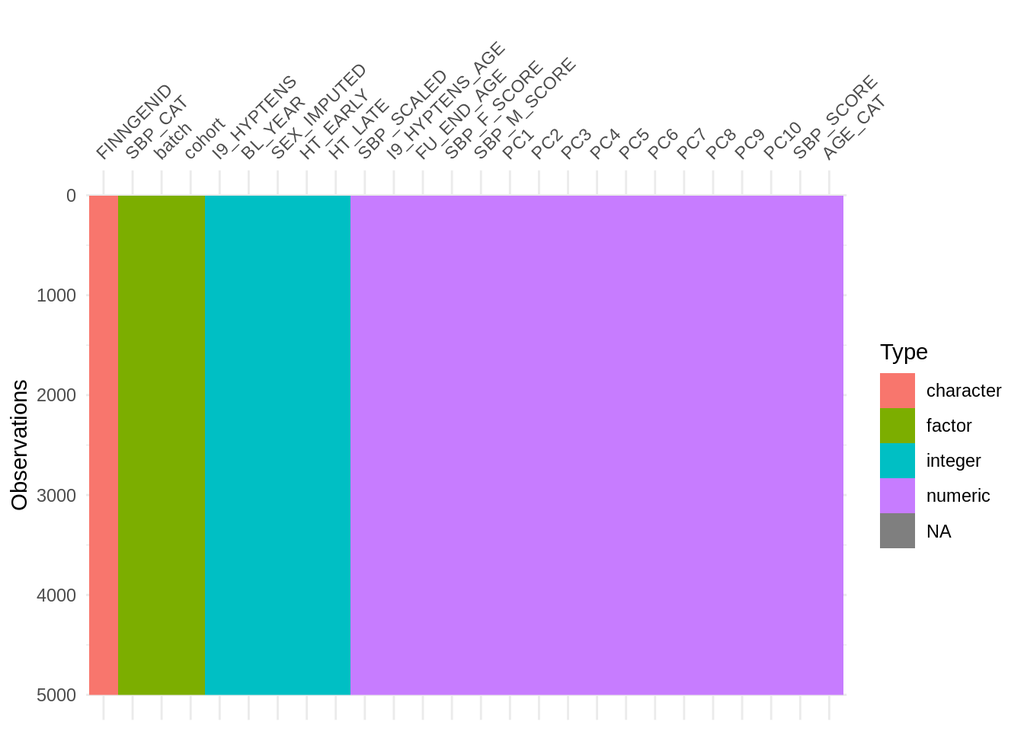

```r
#5000 random observations
df %>%
  sample_n(5000) %>%
  vis_dat()
```

```r
#Risk scores

df_tmp_f <- df_f %>% select(I9_HYPTENS_AGE, I9_HYPTENS, SBP_SCALED, SBP_CAT)
summary(df_tmp_f)
```

```
##  I9_HYPTENS_AGE     I9_HYPTENS       SBP_SCALED.V1        SBP_CAT
##  Min.   :  0.04   Min.   :0.000   Min.   :-4.548580   <2.5%   : 3090
##  1st Qu.: 41.20   1st Qu.:0.000   1st Qu.:-0.676014   2.5-20% :21626
##  Median : 54.70   Median :0.000   Median :-0.000140   20-80%  :74147
##  Mean   : 53.58   Mean   :0.225   Mean   : 0.000000   80-97.5%:21626
##  3rd Qu.: 66.12   3rd Qu.:0.000   3rd Qu.: 0.677318   >97.5%  : 3090
##  Max.   :117.36   Max.   :1.000   Max.   : 4.113703
##                   NA's   :25
```

```r
df_tmp_m <- df_m %>% select(I9_HYPTENS_AGE, I9_HYPTENS, SBP_SCALED, SBP_CAT)
summary(df_tmp_m)
```

```
##  I9_HYPTENS_AGE     I9_HYPTENS        SBP_SCALED.V1        SBP_CAT
##  Min.   :  0.04   Min.   :0.0000   Min.   :-4.399230   <2.5%   : 2381
##  1st Qu.: 44.81   1st Qu.:0.0000   1st Qu.:-0.671980   2.5-20% :16662
##  Median : 57.09   Median :0.0000   Median :-0.002879   20-80%  :57127
##  Mean   : 55.92   Mean   :0.2953   Mean   : 0.000000   80-97.5%:16662
##  3rd Qu.: 67.88   3rd Qu.:1.0000   3rd Qu.: 0.674310   >97.5%  : 2381
##  Max.   :118.92   Max.   :1.0000   Max.   : 4.541880
##                   NA's   :13
```

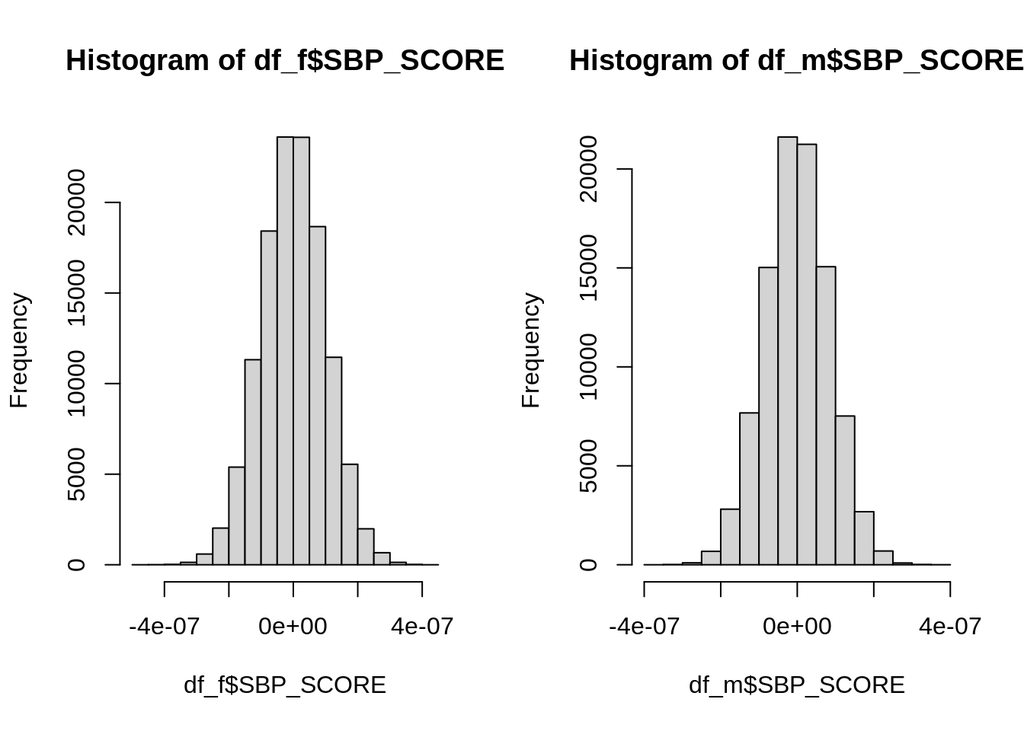

```r
par(mfrow=c(1,2))
hist(df_f$SBP_SCORE)
hist(df_m$SBP_SCORE)
```

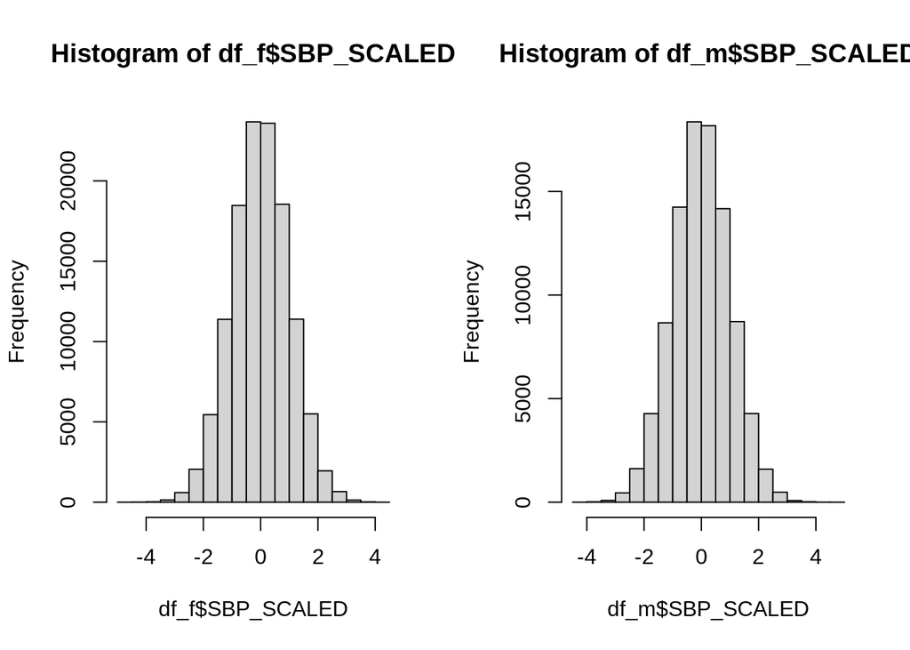

```r
par(mfrow=c(1,1))

par(mfrow=c(1,2))
hist(df_f$SBP_SCALED)
hist(df_m$SBP_SCALED)
```

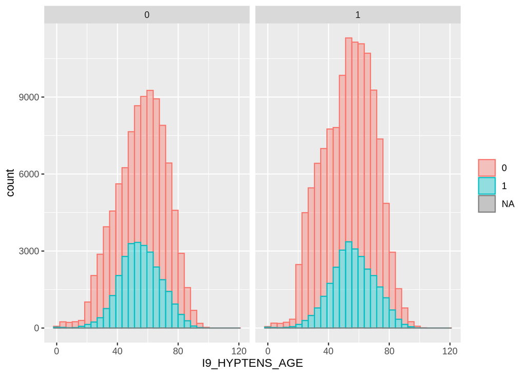

```r
par(mfrow=c(1,1))

#Visualisation of endpoints

ggplot(df, aes(x=I9_HYPTENS_AGE, color=as.factor(I9_HYPTENS), fill=as.factor(I9_HYPTENS))) +
    geom_histogram(alpha=0.4) +
    theme(legend.title = element_blank()) +
    facet_wrap(~SEX_IMPUTED, ncol=2)
```

# 2 BP PRSs and hypertension

## 2.1 Proportional hazard assumption: log log curve

**Model by survfit**

```r
km.sbp.f <- survfit(Surv(I9_HYPTENS_AGE, I9_HYPTENS) ~ SBP_CAT, data=df_f)
#print(km.sbp)
km.sbp.m <- survfit(Surv(I9_HYPTENS_AGE, I9_HYPTENS) ~ SBP_CAT, data=df_m)
#print(km.sbp)
```

**KM plot**

[figure not shown]

```r
p.f <- my_ggkmplot(km.sbp.f, "HT vs. SBP score")
p.m <- my_ggkmplot(km.sbp.m, "HT vs. DBP score")

splots <- arrange_ggsurvplots(list(p.f, p.m),
                            nrow = 1, ncol = 2,
                            title = "Kaplan Meier curve")
```

```r
ggsave(file = "km_ht_prs.png", plot = splots, height = 4, width = 10, dpi = 150)
```

**log log curve**

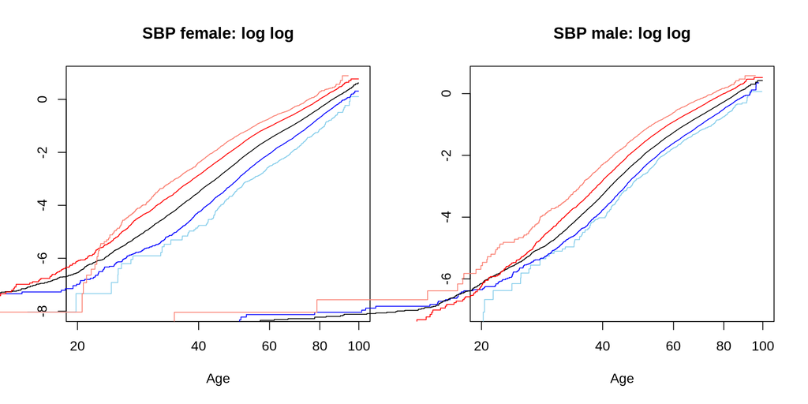

```r
cols= c("skyblue", "blue", "black", "red", "salmon")
labels= c("<2.5%","2.5-20%","20-80%","80-97.5%",">97.5%")

par(mfrow=c(1,2))

plot(km.sbp.f, fun="cloglog", xlim=c(20,100), main="SBP female: log log", xlab="Age", col = cols)
plot(km.sbp.m, fun="cloglog", xlim=c(20,100), main="SBP male: log log", xlab="Age", col = cols)
```

```r
par(mfrow=c(1,1))
```

These look parallel enough. We can use cox model.

## 2.2 Cox model: covariate adjusted, continuous score

**Running models**

```r
#Fitting cox for females
cx.sbp.cs.f <- coxph(Surv(I9_HYPTENS_AGE, I9_HYPTENS) ~ SBP_SCALED + batch + BL_YEAR + PC1 + PC2 + PC3 + PC4 + PC5 + PC6 + PC7 + PC8 + PC9 + PC10, data=df_f)

#Fitting cox for males
cx.sbp.cs.m <- coxph(Surv(I9_HYPTENS_AGE, I9_HYPTENS) ~ SBP_SCALED + batch + BL_YEAR + PC1 + PC2 + PC3 + PC4 + PC5 + PC6 + PC7 + PC8 + PC9 + PC10, data=df_m)
```

**Table: Hazard rations:**

```r
my_hr_table_cont2(list(cx.sbp.cs.f, cx.sbp.cs.m), c("SBP female", "SBP male")) %>%
  kable() %>%
  kable_styling(full_width =  F)
```

| name | HR (95% CI) | P-value |
| --- | --- | --- |
| SBP female | 1.42 (1.4, 1.44) | <1e-300 |
| SBP male | 1.27 (1.26, 1.29) | <1e-300 |

**All coefficients**

```r
summary(cx.sbp.cs.f)
```

```
## Call:
## coxph(formula = Surv(I9_HYPTENS_AGE, I9_HYPTENS) ~ SBP_SCALED +
##     batch + BL_YEAR + PC1 + PC2 + PC3 + PC4 + PC5 + PC6 + PC7 +
##     PC8 + PC9 + PC10, data = df_f)
##
##   n= 123554, number of events= 27804
##    (25 observations deleted due to missingness)
##
##                                                        coef  exp(coef)
## SBP_SCALED                                        0.3513531  1.4209890
## batchAxiomGT1_b02_V2P2.calls                     -0.1787680  0.8362999
## batchAxiomGT1_b03_V2P2.calls                      0.0655261  1.0677206
## batchAxiomGT1_b04_V2P2.calls                      0.1776429  1.1943987
## batchAxiomGT1_b05_V2P2.calls                     -0.0236662  0.9766117
## batchAxiomGT1_b06_V2P2.calls                     -0.0479457  0.9531855
## batchAxiomGT1_b07_V2P2.calls                     -0.0030589  0.9969458
## batchAxiomGT1_b08_V2P2.calls                     -0.0313676  0.9691193
## batchAxiomGT1_b09_V2P2.calls                     -0.0449621  0.9560337
## batchAxiomGT1_b10_V2P2.calls                      0.1533788  1.1657664
## batchAxiomGT1_b11_V2P2.calls                      0.1520056  1.1641668
## batchAxiomGT1_b12_V2P2.calls                      0.1366348  1.1464094
## batchAxiomGT1_b13_V2P2.calls                      0.3184064  1.3749350
## batchAxiomGT1_b14_V2P2.calls                      0.0985347  1.1035527
## batchAxiomGT1_b15_V2P2.calls                      0.3775260  1.4586713
## batchAxiomGT1_b16_V2P2.calls                     -0.1017502  0.9032552
## batchAxiomGT1_b17_V2P2.calls                      0.1885493  1.2074966
## batchAxiomGT1_b18_V2P2.calls                      0.4579895  1.5808923
## batchAxiomGT1_b19_V2P2.calls                     -0.2242830  0.7990890
## batchAxiomGT1_b20_V2P2.calls                      0.2814169  1.3250059
## batchAxiomGT1_b21_V2P2.calls                      0.1178223  1.1250442
## batchAxiomGT1_b22_V2P2.calls                      0.3868461  1.4723299
## batchAxiomGT1_b23_V2P2.calls                      0.1642791  1.1785432
## batchAxiomGT1_b24_V2P2.calls                     -0.1848677  0.8312143
## batchAxiomGT1_b25_V2P2.calls                      0.2001477  1.2215832
## batchAxiomGT1_b26_V2P2.calls                      0.2486303  1.2822679
## batchAxiomGT1_b27_V2P2.calls                     -0.3918603  0.6757985
## batchAxiomGT1_b28_V2P2.calls                      0.0615995  1.0635363
## batchAxiomGT1_b29_V2P2.calls                      0.2780235  1.3205172
## batchAxiomGT1_b30_V2P2.calls                      0.2254703  1.2529119
## batchAxiomGT1_b31_V2.calls                        0.0426414  1.0435636
```

[output cut: 336 more lines]

```
## PC1                                               0.044695
## PC2                                              34.307666
## PC3                                               1.416230
## PC4                                               0.080376
## PC5                                              22.157729
## PC6                                               5.262900
## PC7                                               1.885245
## PC8                                               1.488880
## PC9                                               7.865844
## PC10                                              0.003141
##
## Concordance= 0.633  (se = 0.002 )
## Likelihood ratio test= 4836  on 74 df,   p=<2e-16
## Wald test            = 4828  on 74 df,   p=<2e-16
## Score (logrank) test = 4868  on 74 df,   p=<2e-16
```

```r
summary(cx.sbp.cs.m)
```

```
## Call:
## coxph(formula = Surv(I9_HYPTENS_AGE, I9_HYPTENS) ~ SBP_SCALED +
##     batch + BL_YEAR + PC1 + PC2 + PC3 + PC4 + PC5 + PC6 + PC7 +
##     PC8 + PC9 + PC10, data = df_m)
##
##   n= 95200, number of events= 28113
##    (13 observations deleted due to missingness)
##
##                                                       coef exp(coef)  se(coef)
## SBP_SCALED                                        0.242600  1.274558  0.006157
## batchAxiomGT1_b02_V2P2.calls                     -0.123133  0.884146  0.065773
## batchAxiomGT1_b03_V2P2.calls                     -0.101365  0.903604  0.069578
## batchAxiomGT1_b04_V2P2.calls                      0.116251  1.123278  0.062193
## batchAxiomGT1_b05_V2P2.calls                     -0.101367  0.903602  0.065071
## batchAxiomGT1_b06_V2P2.calls                      0.080643  1.083983  0.063085
## batchAxiomGT1_b07_V2P2.calls                      0.034802  1.035415  0.062994
## batchAxiomGT1_b08_V2P2.calls                     -0.076775  0.926098  0.066773
## batchAxiomGT1_b09_V2P2.calls                      0.106882  1.112803  0.066583
## batchAxiomGT1_b10_V2P2.calls                      0.145241  1.156318  0.063104
## batchAxiomGT1_b11_V2P2.calls                      0.114378  1.121176  0.065277
## batchAxiomGT1_b12_V2P2.calls                      0.076240  1.079221  0.083582
## batchAxiomGT1_b13_V2P2.calls                      0.320149  1.377333  0.061930
## batchAxiomGT1_b14_V2P2.calls                      0.143559  1.154375  0.068055
## batchAxiomGT1_b15_V2P2.calls                      0.321836  1.379659  0.065825
## batchAxiomGT1_b16_V2P2.calls                     -0.175043  0.839421  0.081648
## batchAxiomGT1_b17_V2P2.calls                      0.097752  1.102689  0.067619
## batchAxiomGT1_b18_V2P2.calls                      0.388210  1.474340  0.057767
## batchAxiomGT1_b19_V2P2.calls                     -0.241068  0.785788  0.091257
## batchAxiomGT1_b20_V2P2.calls                      0.375796  1.456150  0.060670
## batchAxiomGT1_b21_V2P2.calls                      0.201944  1.223780  0.064112
## batchAxiomGT1_b22_V2P2.calls                      0.334513  1.397260  0.062251
## batchAxiomGT1_b23_V2P2.calls                      0.205929  1.228666  0.067017
## batchAxiomGT1_b24_V2P2.calls                     -0.273744  0.760527  0.086250
## batchAxiomGT1_b25_V2P2.calls                      0.213838  1.238421  0.064194
## batchAxiomGT1_b26_V2P2.calls                      0.271428  1.311837  0.064531
## batchAxiomGT1_b27_V2P2.calls                     -0.405953  0.666342  0.094818
## batchAxiomGT1_b28_V2P2.calls                      0.109347  1.115549  0.066581
## batchAxiomGT1_b29_V2P2.calls                      0.242139  1.273972  0.063401
## batchAxiomGT1_b30_V2P2.calls                      0.167191  1.181980  0.068079
## batchAxiomGT1_b31_V2.calls                        0.088349  1.092369  0.070634
```

[output cut: 261 more lines]

```
## PC1                                                 0.1358
## PC2                                                34.0835
## PC3                                                 0.6966
## PC4                                                 0.1007
## PC5                                               165.1286
## PC6                                                21.2611
## PC7                                                 3.1914
## PC8                                                 7.1572
## PC9                                                 2.2543
## PC10                                                0.5586
##
## Concordance= 0.606  (se = 0.002 )
## Likelihood ratio test= 3117  on 74 df,   p=<2e-16
## Wald test            = 3107  on 74 df,   p=<2e-16
## Score (logrank) test = 3141  on 74 df,   p=<2e-16
```

## 2.3 Cox model: adjusted, continuous, by age

**Running the model:**

*Female*

```r
#Young
cx.sbp.cs.y.f <- coxph(Surv(I9_HYPTENS_AGE, HT_EARLY)
                       ~ SBP_SCALED + batch + BL_YEAR + PC1 + PC2 + PC3 + PC4 + PC5 + PC6 + PC7 + PC8 + PC9 + PC10, data=df_f)

#Old
cx.sbp.cs.o.f <- coxph(Surv(I9_HYPTENS_AGE, HT_LATE)
                       ~ SBP_SCALED + batch + BL_YEAR + PC1 + PC2 + PC3 + PC4 + PC5 + PC6 + PC7 + PC8 + PC9 + PC10, data=df_f)
```

*Male*

```r
#Young
cx.sbp.cs.y.m <- coxph(Surv(I9_HYPTENS_AGE, HT_EARLY)
                       ~ SBP_SCALED + batch + BL_YEAR + PC1 + PC2 + PC3 + PC4 + PC5 + PC6 + PC7 + PC8 + PC9 + PC10, data=df_m)

#Old
cx.sbp.cs.o.m <- coxph(Surv(I9_HYPTENS_AGE, HT_LATE)
                       ~ SBP_SCALED + batch + BL_YEAR + PC1 + PC2 + PC3 + PC4 + PC5 + PC6 + PC7 + PC8 + PC9 + PC10, data=df_m)
```

**Hazard ratios**

```r
my_hr_table_cont2(list(cx.sbp.cs.y.f, cx.sbp.cs.o.f, cx.sbp.cs.y.m,  cx.sbp.cs.o.m),
                  c("Early female", "Late female", "Early male", "Late male")) %>%
  kable()%>%
  kable_styling(full_width =  F)
```

| name | HR (95% CI) | P-value |
| --- | --- | --- |
| Early female | 1.56 (1.53, 1.58) | <1e-300 |
| Late female | 1.31 (1.28, 1.33) | 3e-204 |
| Early male | 1.35 (1.32, 1.37) | 2e-257 |
| Late male | 1.21 (1.19, 1.23) | 3e-102 |

**Interaction term**

```r
#All ages
cx.sbp.cs.i <- coxph(Surv(I9_HYPTENS_AGE, I9_HYPTENS) ~ SBP_SCALED*SEX_IMPUTED
                  + batch + BL_YEAR + PC1 + PC2 + PC3 + PC4 + PC5 + PC6 + PC7 + PC8 + PC9 + PC10, data=df_r)

#Early
cx.sbp.cs.y.i <- coxph(Surv(I9_HYPTENS_AGE, HT_EARLY) ~ SBP_SCALED*SEX_IMPUTED
                  + batch + BL_YEAR + PC1 + PC2 + PC3 + PC4 + PC5 + PC6 + PC7 + PC8 + PC9 + PC10, data=df_r)

#Late
cx.sbp.cs.o.i <- coxph(Surv(I9_HYPTENS_AGE, HT_LATE) ~ SBP_SCALED*SEX_IMPUTED
                  + batch + BL_YEAR + PC1 + PC2 + PC3 + PC4 + PC5 + PC6 + PC7 + PC8 + PC9 + PC10, data=df_r)


int_table.cs <-
  rbind(my_extr_coef(cx.sbp.cs.i, "All", ":SEX"),
        my_extr_coef(cx.sbp.cs.y.i, "Early", ":SEX"),
        my_extr_coef(cx.sbp.cs.o.i, "Late", ":SEX")) %>%
  my_tidy_table() %>%
  kable() %>%
  kable_styling(full_width =  F)
```

## 2.4 Cox model: covariate adjusted, categorized score

We will run divide data by gender and by age

**Running models**

*Female*

```r
#All ages
cx.sbp.f <- coxph(Surv(I9_HYPTENS_AGE, I9_HYPTENS) ~ SBP_CAT
                  + batch + BL_YEAR + PC1 + PC2 + PC3 + PC4 + PC5 + PC6 + PC7 + PC8 + PC9 + PC10, data=df_fr)

#Young
cx.sbp.y.f <- coxph(Surv(I9_HYPTENS_AGE, HT_EARLY) ~ SBP_CAT
                    + batch + BL_YEAR + PC1 + PC2 + PC3 + PC4 + PC5 + PC6 + PC7 + PC8 + PC9 + PC10, data=df_fr)

#Old
cx.sbp.o.f <- coxph(Surv(I9_HYPTENS_AGE, HT_LATE) ~ SBP_CAT
                    + batch + BL_YEAR + PC1 + PC2 + PC3 + PC4 + PC5 + PC6 + PC7 + PC8 + PC9 + PC10, data=df_fr)
```

*Male*

```r
#All ages
cx.sbp.m <- coxph(Surv(I9_HYPTENS_AGE, I9_HYPTENS) ~ SBP_CAT
                  + batch + BL_YEAR + PC1 + PC2 + PC3 + PC4 + PC5 + PC6 + PC7 + PC8 + PC9 + PC10, data=df_mr)

#Young
cx.sbp.y.m <- coxph(Surv(I9_HYPTENS_AGE, HT_EARLY) ~ SBP_CAT
                    + batch + BL_YEAR + PC1 + PC2 + PC3 + PC4 + PC5 + PC6 + PC7 + PC8 + PC9 + PC10, data=df_mr)

#Old
cx.sbp.o.m <- coxph(Surv(I9_HYPTENS_AGE, HT_LATE) ~ SBP_CAT
                    + batch + BL_YEAR + PC1 + PC2 + PC3 + PC4 + PC5 + PC6 + PC7 + PC8 + PC9 + PC10, data=df_mr)
```

**Interaction term**

We will check if differences between genders is statistically different by examing the interaction term.

```r
#All ages
cx.sbp.i <- coxph(Surv(I9_HYPTENS_AGE, I9_HYPTENS) ~ SBP_CAT*SEX_IMPUTED
                  + batch + BL_YEAR + PC1 + PC2 + PC3 + PC4 + PC5 + PC6 + PC7 + PC8 + PC9 + PC10, data=df_r)

#All ages
cx.sbp.y.i <- coxph(Surv(I9_HYPTENS_AGE, HT_EARLY) ~ SBP_CAT*SEX_IMPUTED
                  + batch + BL_YEAR + PC1 + PC2 + PC3 + PC4 + PC5 + PC6 + PC7 + PC8 + PC9 + PC10, data=df_r)

#All ages
cx.sbp.o.i <- coxph(Surv(I9_HYPTENS_AGE, HT_LATE) ~ SBP_CAT*SEX_IMPUTED
                  + batch + BL_YEAR + PC1 + PC2 + PC3 + PC4 + PC5 + PC6 + PC7 + PC8 + PC9 + PC10, data=df_r)


int_table <-
  my_extr_coef(cx.sbp.i, "", ":SEX") %>%
  my_tidy_table() %>%
  select(-name) %>%
  kable() %>%
  kable_styling(full_width =  F)
```

**Table: Hazard ratios:**

```r
table.hr.f <-
  my_hr_table3_notitle(cx.sbp.f, cx.sbp.y.f, cx.sbp.o.f, dfs=list(df_f, df_f, df_f)) %>%
  mutate("P-value" = sub("e(-\\d+)", "x10<sup>\\1</sup>", `P-value`, perl=T))   #html-version/proper exponents
  #mutate("P-value" = sub("e(-\\d+)", "%*%10^{\\1}", `P-value`, perl=T))        #latex-version/proper exponents

table.hr.m <-
  my_hr_table3_notitle(cx.sbp.m, cx.sbp.y.m, cx.sbp.o.m, dfs=list(df_m, df_m, df_m)) %>%
  select(-PRS) %>%
  mutate("P-value" = sub("e(-\\d+)", "x10<sup>\\1</sup>", `P-value`, perl=T))   #html-version

table.i.term <-
  my_hr_table3_notitle(cx.sbp.i, cx.sbp.y.i, cx.sbp.o.i, dfs=list(df, df, df), select=":SEX") %>%
  select(`P-value`) %>%
  mutate("P-value" = sub("e(-\\d+)", "x10<sup>\\1</sup>", `P-value`, perl=T))   #html-version

hr_table <- cbind(table.hr.f, table.hr.m, table.i.term) %>%
  kable(format="html", escape = F) %>%
  pack_rows("Early", 6, 10, bold=T) %>%
  pack_rows("Late", 11, 15, bold=T) %>%
  kable_classic_2() %>%
  add_header_above(c(" ", "Female" = 3, "Male" = 3, "Interaction" = 1), bold=T) %>%
  row_spec(0,bold=T)

hr_table %>% save_kable("hr_table_sex.html")
hr_table
```

Female

Male

Interaction

PRS

HR (95% CI)

P-value

Cases / Controls

HR (95% CI)

P-value

Cases / Controls

P-value

<2.5%

0.41 (0.37, 0.45)

8x10<sup>-60</sup>

340 / 2749

0.61 (0.56, 0.67)

5x10<sup>-26</sup>

485 / 1896

9x10<sup>-08</sup>

2.5-20%

0.64 (0.61, 0.66)

1x10<sup>-126</sup>

3401 / 18221

0.75 (0.72, 0.77)

2x10<sup>-61</sup>

3966 / 12694

1x10<sup>-08</sup>

20-80%

1 (reference)

16510 / 57621

1 (reference)

16661 / 40456

80-97.5%

1.52 (1.48, 1.57)

7x10<sup>-177</sup>

6451 / 15172

1.37 (1.33, 1.41)

3x10<sup>-94</sup>

5978 / 10683

1x10<sup>-05</sup>

>97.5%

2.12 (1.99, 2.25)

2x10<sup>-126</sup>

1102 / 1987

1.8 (1.69, 1.92)

5x10<sup>-74</sup>

1023 / 1358

0.003

**Early**

<2.5%

0.33 (0.28, 0.4)

2x10<sup>-30</sup>

111 / 2979

0.6 (0.53, 0.69)

4x10<sup>-13</sup>

213 / 2168

1x10<sup>-06</sup>

2.5-20%

0.54 (0.5, 0.57)

3x10<sup>-91</sup>

1236 / 20389

0.7 (0.66, 0.74)

1x10<sup>-40</sup>

1706 / 14955

2x10<sup>-10</sup>

20-80%

1 (reference)

7612 / 66530

1 (reference)

8150 / 48974

80-97.5%

1.71 (1.65, 1.78)

2x10<sup>-153</sup>

3618 / 18007

1.47 (1.41, 1.53)

8x10<sup>-77</sup>

3353 / 13309

5x10<sup>-07</sup>

>97.5%

2.51 (2.32, 2.72)

7x10<sup>-119</sup>

702 / 2387

2.1 (1.94, 2.28)

2x10<sup>-74</sup>

660 / 1721

0.005

**Late**

<2.5%

0.46 (0.4, 0.52)

2x10<sup>-31</sup>

229 / 2860

0.62 (0.55, 0.7)

9x10<sup>-15</sup>

272 / 2109

0.002

2.5-20%

0.71 (0.68, 0.74)

1x10<sup>-45</sup>

2165 / 19458

0.78 (0.75, 0.82)

1x10<sup>-24</sup>

2260 / 14401

0.005

20-80%

1 (reference)

8898 / 65238

1 (reference)

8511 / 48609

80-97.5%

1.34 (1.28, 1.39)

3x10<sup>-40</sup>

2833 / 18791

1.26 (1.21, 1.32)

4x10<sup>-25</sup>

2625 / 14036

0.1

>97.5%

1.66 (1.5, 1.84)

5x10<sup>-23</sup>

400 / 2690

1.45 (1.3, 1.61)

7x10<sup>-12</sup>

363 / 2018

0.09

**All coefficients**

```r
summary(cx.sbp.f)
```

```
## Call:
## coxph(formula = Surv(I9_HYPTENS_AGE, I9_HYPTENS) ~ SBP_CAT +
##     batch + BL_YEAR + PC1 + PC2 + PC3 + PC4 + PC5 + PC6 + PC7 +
##     PC8 + PC9 + PC10, data = df_fr)
##
##   n= 123554, number of events= 27804
##    (25 observations deleted due to missingness)
##
##                                                       coef exp(coef)  se(coef)
## SBP_CAT<2.5%                                     -0.896428  0.408025  0.054952
## SBP_CAT2.5-20%                                   -0.453660  0.635299  0.018952
## SBP_CAT80-97.5%                                   0.420972  1.523442  0.014845
## SBP_CAT>97.5%                                     0.750213  2.117450  0.031356
## batchAxiomGT1_b02_V2P2.calls                     -0.181278  0.834203  0.064995
## batchAxiomGT1_b03_V2P2.calls                      0.050462  1.051757  0.064949
## batchAxiomGT1_b04_V2P2.calls                      0.165532  1.180021  0.058341
## batchAxiomGT1_b05_V2P2.calls                     -0.034587  0.966004  0.061991
## batchAxiomGT1_b06_V2P2.calls                     -0.045700  0.955329  0.063013
## batchAxiomGT1_b07_V2P2.calls                     -0.012579  0.987500  0.061232
## batchAxiomGT1_b08_V2P2.calls                     -0.040931  0.959895  0.063341
## batchAxiomGT1_b09_V2P2.calls                     -0.052580  0.948778  0.067584
## batchAxiomGT1_b10_V2P2.calls                      0.149262  1.160978  0.060642
## batchAxiomGT1_b11_V2P2.calls                      0.144907  1.155932  0.064883
## batchAxiomGT1_b12_V2P2.calls                      0.133783  1.143145  0.080919
## batchAxiomGT1_b13_V2P2.calls                      0.319223  1.376058  0.060779
## batchAxiomGT1_b14_V2P2.calls                      0.088931  1.093006  0.064355
## batchAxiomGT1_b15_V2P2.calls                      0.367305  1.443838  0.065743
## batchAxiomGT1_b16_V2P2.calls                     -0.108253  0.897401  0.080432
## batchAxiomGT1_b17_V2P2.calls                      0.185609  1.203951  0.063593
## batchAxiomGT1_b18_V2P2.calls                      0.443053  1.557455  0.058531
## batchAxiomGT1_b19_V2P2.calls                     -0.230540  0.794104  0.085642
## batchAxiomGT1_b20_V2P2.calls                      0.267135  1.306217  0.060155
## batchAxiomGT1_b21_V2P2.calls                      0.109389  1.115596  0.063552
## batchAxiomGT1_b22_V2P2.calls                      0.377049  1.457976  0.060584
## batchAxiomGT1_b23_V2P2.calls                      0.152575  1.164830  0.066624
## batchAxiomGT1_b24_V2P2.calls                     -0.188826  0.827931  0.085608
## batchAxiomGT1_b25_V2P2.calls                      0.192028  1.211704  0.061993
## batchAxiomGT1_b26_V2P2.calls                      0.246640  1.279719  0.062077
## batchAxiomGT1_b27_V2P2.calls                     -0.392116  0.675626  0.093865
## batchAxiomGT1_b28_V2P2.calls                      0.055976  1.057572  0.066584
```

[output cut: 273 more lines]

```
## PC1                                                0.03548
## PC2                                               32.53252
## PC3                                                1.70850
## PC4                                                0.17721
## PC5                                               25.48845
## PC6                                                4.77358
## PC7                                                2.01035
## PC8                                                1.53713
## PC9                                                7.00622
## PC10                                               0.02226
##
## Concordance= 0.625  (se = 0.002 )
## Likelihood ratio test= 4230  on 77 df,   p=<2e-16
## Wald test            = 4183  on 77 df,   p=<2e-16
## Score (logrank) test = 4349  on 77 df,   p=<2e-16
```

```r
summary(cx.sbp.m)
```

```
## Call:
## coxph(formula = Surv(I9_HYPTENS_AGE, I9_HYPTENS) ~ SBP_CAT +
##     batch + BL_YEAR + PC1 + PC2 + PC3 + PC4 + PC5 + PC6 + PC7 +
##     PC8 + PC9 + PC10, data = df_mr)
##
##   n= 95200, number of events= 28113
##    (13 observations deleted due to missingness)
##
##                                                       coef exp(coef)  se(coef)
## SBP_CAT<2.5%                                     -0.487368  0.614241  0.046208
## SBP_CAT2.5-20%                                   -0.293859  0.745382  0.017776
## SBP_CAT80-97.5%                                   0.313046  1.367585  0.015197
## SBP_CAT>97.5%                                     0.589739  1.803517  0.032391
## batchAxiomGT1_b02_V2P2.calls                     -0.127955  0.879893  0.065775
## batchAxiomGT1_b03_V2P2.calls                     -0.108615  0.897076  0.069581
## batchAxiomGT1_b04_V2P2.calls                      0.110108  1.116398  0.062189
## batchAxiomGT1_b05_V2P2.calls                     -0.107400  0.898166  0.065076
## batchAxiomGT1_b06_V2P2.calls                      0.077557  1.080644  0.063079
## batchAxiomGT1_b07_V2P2.calls                      0.030386  1.030852  0.062985
## batchAxiomGT1_b08_V2P2.calls                     -0.089832  0.914085  0.066779
## batchAxiomGT1_b09_V2P2.calls                      0.100471  1.105692  0.066584
## batchAxiomGT1_b10_V2P2.calls                      0.136653  1.146430  0.063109
## batchAxiomGT1_b11_V2P2.calls                      0.112655  1.119245  0.065280
## batchAxiomGT1_b12_V2P2.calls                      0.065230  1.067405  0.083583
## batchAxiomGT1_b13_V2P2.calls                      0.309827  1.363190  0.061933
## batchAxiomGT1_b14_V2P2.calls                      0.135024  1.144565  0.068048
## batchAxiomGT1_b15_V2P2.calls                      0.314783  1.369963  0.065808
## batchAxiomGT1_b16_V2P2.calls                     -0.183618  0.832253  0.081640
## batchAxiomGT1_b17_V2P2.calls                      0.093860  1.098406  0.067620
## batchAxiomGT1_b18_V2P2.calls                      0.386694  1.472106  0.057764
## batchAxiomGT1_b19_V2P2.calls                     -0.246250  0.781727  0.091253
## batchAxiomGT1_b20_V2P2.calls                      0.367938  1.444752  0.060665
## batchAxiomGT1_b21_V2P2.calls                      0.196160  1.216722  0.064111
## batchAxiomGT1_b22_V2P2.calls                      0.325696  1.384994  0.062240
## batchAxiomGT1_b23_V2P2.calls                      0.205882  1.228608  0.067016
## batchAxiomGT1_b24_V2P2.calls                     -0.278582  0.756856  0.086253
## batchAxiomGT1_b25_V2P2.calls                      0.209108  1.232578  0.064186
## batchAxiomGT1_b26_V2P2.calls                      0.263203  1.301091  0.064533
## batchAxiomGT1_b27_V2P2.calls                     -0.405181  0.666856  0.094814
## batchAxiomGT1_b28_V2P2.calls                      0.103152  1.108660  0.066572
```

[output cut: 273 more lines]

```
## PC1                                                 0.1155
## PC2                                                29.9380
## PC3                                                 0.7479
## PC4                                                 0.1980
## PC5                                               168.3630
## PC6                                                15.9779
## PC7                                                 3.3671
## PC8                                                 6.6424
## PC9                                                 2.5343
## PC10                                                1.2893
##
## Concordance= 0.601  (se = 0.002 )
## Likelihood ratio test= 2838  on 77 df,   p=<2e-16
## Wald test            = 2852  on 77 df,   p=<2e-16
## Score (logrank) test = 2922  on 77 df,   p=<2e-16
```

```r
summary(cx.sbp.y.f)
```

```
## Call:
## coxph(formula = Surv(I9_HYPTENS_AGE, HT_EARLY) ~ SBP_CAT + batch +
##     BL_YEAR + PC1 + PC2 + PC3 + PC4 + PC5 + PC6 + PC7 + PC8 +
##     PC9 + PC10, data = df_fr)
##
##   n= 123571, number of events= 13279
##    (8 observations deleted due to missingness)
##
##                                                       coef exp(coef)  se(coef)
## SBP_CAT<2.5%                                     -1.098305  0.333436  0.095781
## SBP_CAT2.5-20%                                   -0.624288  0.535643  0.030815
## SBP_CAT80-97.5%                                   0.538205  1.712929  0.020401
## SBP_CAT>97.5%                                     0.921599  2.513305  0.039760
## batchAxiomGT1_b02_V2P2.calls                     -0.003903  0.996104  0.098687
## batchAxiomGT1_b03_V2P2.calls                      0.161771  1.175591  0.096303
## batchAxiomGT1_b04_V2P2.calls                      0.331001  1.392361  0.090196
## batchAxiomGT1_b05_V2P2.calls                      0.162277  1.176186  0.095534
## batchAxiomGT1_b06_V2P2.calls                      0.089417  1.093537  0.097354
## batchAxiomGT1_b07_V2P2.calls                      0.218680  1.244433  0.093280
## batchAxiomGT1_b08_V2P2.calls                      0.171439  1.187012  0.094796
## batchAxiomGT1_b09_V2P2.calls                      0.179684  1.196840  0.096931
## batchAxiomGT1_b10_V2P2.calls                      0.354122  1.424929  0.090766
## batchAxiomGT1_b11_V2P2.calls                      0.296170  1.344699  0.097114
## batchAxiomGT1_b12_V2P2.calls                      0.448977  1.566709  0.113585
## batchAxiomGT1_b13_V2P2.calls                      0.566546  1.762170  0.090962
## batchAxiomGT1_b14_V2P2.calls                      0.235332  1.265329  0.097874
## batchAxiomGT1_b15_V2P2.calls                      0.520322  1.682569  0.096755
## batchAxiomGT1_b16_V2P2.calls                     -0.026261  0.974081  0.116288
## batchAxiomGT1_b17_V2P2.calls                      0.396837  1.487114  0.095183
## batchAxiomGT1_b18_V2P2.calls                      0.623934  1.866256  0.092545
## batchAxiomGT1_b19_V2P2.calls                     -0.189870  0.827067  0.123419
## batchAxiomGT1_b20_V2P2.calls                      0.485160  1.624435  0.091573
## batchAxiomGT1_b21_V2P2.calls                      0.209220  1.232716  0.098288
## batchAxiomGT1_b22_V2P2.calls                      0.577643  1.781834  0.092058
## batchAxiomGT1_b23_V2P2.calls                      0.318376  1.374892  0.100088
## batchAxiomGT1_b24_V2P2.calls                     -0.034730  0.965866  0.117993
## batchAxiomGT1_b25_V2P2.calls                      0.443537  1.558208  0.092529
## batchAxiomGT1_b26_V2P2.calls                      0.476520  1.610460  0.092430
## batchAxiomGT1_b27_V2P2.calls                     -0.187811  0.828771  0.122381
## batchAxiomGT1_b28_V2P2.calls                      0.242648  1.274620  0.100022
```

[output cut: 273 more lines]

```
## PC1                                              6.067e-03
## PC2                                              6.208e+01
## PC3                                              1.604e+00
## PC4                                              1.798e-01
## PC5                                              1.674e+02
## PC6                                              3.555e+01
## PC7                                              7.211e+00
## PC8                                              1.100e+00
## PC9                                              4.296e+01
## PC10                                             2.068e-02
##
## Concordance= 0.641  (se = 0.002 )
## Likelihood ratio test= 3252  on 77 df,   p=<2e-16
## Wald test            = 3203  on 77 df,   p=<2e-16
## Score (logrank) test = 3406  on 77 df,   p=<2e-16
```

```r
summary(cx.sbp.y.m)
```

```
## Call:
## coxph(formula = Surv(I9_HYPTENS_AGE, HT_EARLY) ~ SBP_CAT + batch +
##     BL_YEAR + PC1 + PC2 + PC3 + PC4 + PC5 + PC6 + PC7 + PC8 +
##     PC9 + PC10, data = df_mr)
##
##   n= 95209, number of events= 14082
##    (4 observations deleted due to missingness)
##
##                                                        coef  exp(coef)
## SBP_CAT<2.5%                                      -0.503983   0.604120
## SBP_CAT2.5-20%                                    -0.357541   0.699394
## SBP_CAT80-97.5%                                    0.383633   1.467607
## SBP_CAT>97.5%                                      0.743083   2.102406
## batchAxiomGT1_b02_V2P2.calls                      -0.134005   0.874585
## batchAxiomGT1_b03_V2P2.calls                       0.003381   1.003387
## batchAxiomGT1_b04_V2P2.calls                       0.265482   1.304059
## batchAxiomGT1_b05_V2P2.calls                       0.003239   1.003244
## batchAxiomGT1_b06_V2P2.calls                       0.157471   1.170547
## batchAxiomGT1_b07_V2P2.calls                       0.121997   1.129750
## batchAxiomGT1_b08_V2P2.calls                       0.002330   1.002332
## batchAxiomGT1_b09_V2P2.calls                       0.252121   1.286752
## batchAxiomGT1_b10_V2P2.calls                       0.279029   1.321846
## batchAxiomGT1_b11_V2P2.calls                       0.269511   1.309324
## batchAxiomGT1_b12_V2P2.calls                       0.241985   1.273775
## batchAxiomGT1_b13_V2P2.calls                       0.494688   1.639987
## batchAxiomGT1_b14_V2P2.calls                       0.297377   1.346323
## batchAxiomGT1_b15_V2P2.calls                       0.393537   1.482214
## batchAxiomGT1_b16_V2P2.calls                      -0.170196   0.843500
## batchAxiomGT1_b17_V2P2.calls                       0.249859   1.283844
## batchAxiomGT1_b18_V2P2.calls                       0.490020   1.632349
## batchAxiomGT1_b19_V2P2.calls                      -0.143113   0.866656
## batchAxiomGT1_b20_V2P2.calls                       0.491460   1.634702
## batchAxiomGT1_b21_V2P2.calls                       0.447864   1.564966
## batchAxiomGT1_b22_V2P2.calls                       0.487322   1.627951
## batchAxiomGT1_b23_V2P2.calls                       0.234619   1.264427
## batchAxiomGT1_b24_V2P2.calls                      -0.325871   0.721899
## batchAxiomGT1_b25_V2P2.calls                       0.421829   1.524748
## batchAxiomGT1_b26_V2P2.calls                       0.452373   1.572039
## batchAxiomGT1_b27_V2P2.calls                      -0.292877   0.746114
## batchAxiomGT1_b28_V2P2.calls                       0.232287   1.261481
```

[output cut: 351 more lines]

```
## PC1                                              8.709e-03
## PC2                                              1.788e+01
## PC3                                              7.212e-01
## PC4                                              3.511e-01
## PC5                                              3.345e+03
## PC6                                              2.239e+02
## PC7                                              4.107e+00
## PC8                                              1.251e+01
## PC9                                              9.807e+00
## PC10                                             5.710e+00
##
## Concordance= 0.615  (se = 0.002 )
## Likelihood ratio test= 2253  on 77 df,   p=<2e-16
## Wald test            = 2271  on 77 df,   p=<2e-16
## Score (logrank) test = 2347  on 77 df,   p=<2e-16
```

```r
summary(cx.sbp.o.f)
```

```
## Call:
## coxph(formula = Surv(I9_HYPTENS_AGE, HT_LATE) ~ SBP_CAT + batch +
##     BL_YEAR + PC1 + PC2 + PC3 + PC4 + PC5 + PC6 + PC7 + PC8 +
##     PC9 + PC10, data = df_fr)
##
##   n= 123562, number of events= 14525
##    (17 observations deleted due to missingness)
##
##                                                        coef  exp(coef)
## SBP_CAT<2.5%                                     -0.7827870  0.4571302
## SBP_CAT2.5-20%                                   -0.3426711  0.7098716
## SBP_CAT80-97.5%                                   0.2895626  1.3358430
## SBP_CAT>97.5%                                     0.5089013  1.6634625
## batchAxiomGT1_b02_V2P2.calls                     -0.3239254  0.7233042
## batchAxiomGT1_b03_V2P2.calls                     -0.0120256  0.9880464
## batchAxiomGT1_b04_V2P2.calls                      0.0464778  1.0475749
## batchAxiomGT1_b05_V2P2.calls                     -0.1702713  0.8434360
## batchAxiomGT1_b06_V2P2.calls                     -0.1382252  0.8709025
## batchAxiomGT1_b07_V2P2.calls                     -0.1817021  0.8338497
## batchAxiomGT1_b08_V2P2.calls                     -0.2091978  0.8112347
## batchAxiomGT1_b09_V2P2.calls                     -0.2870525  0.7504723
## batchAxiomGT1_b10_V2P2.calls                     -0.0309301  0.9695433
## batchAxiomGT1_b11_V2P2.calls                      0.0390243  1.0397958
## batchAxiomGT1_b12_V2P2.calls                     -0.1729883  0.8411475
## batchAxiomGT1_b13_V2P2.calls                      0.1018834  1.1072543
## batchAxiomGT1_b14_V2P2.calls                     -0.0166749  0.9834633
## batchAxiomGT1_b15_V2P2.calls                      0.2630571  1.3009010
## batchAxiomGT1_b16_V2P2.calls                     -0.1172340  0.8893771
## batchAxiomGT1_b17_V2P2.calls                      0.0024781  1.0024811
## batchAxiomGT1_b18_V2P2.calls                      0.3160356  1.3716791
## batchAxiomGT1_b19_V2P2.calls                     -0.1749370  0.8395099
## batchAxiomGT1_b20_V2P2.calls                      0.0911697  1.0954549
## batchAxiomGT1_b21_V2P2.calls                      0.0346206  1.0352268
## batchAxiomGT1_b22_V2P2.calls                      0.2153862  1.2403408
## batchAxiomGT1_b23_V2P2.calls                      0.0257967  1.0261323
## batchAxiomGT1_b24_V2P2.calls                     -0.2803371  0.7555290
## batchAxiomGT1_b25_V2P2.calls                     -0.0301287  0.9703207
## batchAxiomGT1_b26_V2P2.calls                      0.0457221  1.0467834
## batchAxiomGT1_b27_V2P2.calls                     -0.5419518  0.5816119
## batchAxiomGT1_b28_V2P2.calls                     -0.0950765  0.9093034
```

[output cut: 351 more lines]

```
## PC1                                                0.24096
## PC2                                               33.22530
## PC3                                                3.76802
## PC4                                                0.57960
## PC5                                               12.93583
## PC6                                                2.52232
## PC7                                                2.18484
## PC8                                                7.43902
## PC9                                                5.06277
## PC10                                               0.09544
##
## Concordance= 0.592  (se = 0.003 )
## Likelihood ratio test= 1402  on 77 df,   p=<2e-16
## Wald test            = 1368  on 77 df,   p=<2e-16
## Score (logrank) test = 1403  on 77 df,   p=<2e-16
```

```r
summary(cx.sbp.o.m)
```

```
## Call:
## coxph(formula = Surv(I9_HYPTENS_AGE, HT_LATE) ~ SBP_CAT + batch +
##     BL_YEAR + PC1 + PC2 + PC3 + PC4 + PC5 + PC6 + PC7 + PC8 +
##     PC9 + PC10, data = df_mr)
##
##   n= 95204, number of events= 14031
##    (9 observations deleted due to missingness)
##
##                                                        coef  exp(coef)
## SBP_CAT<2.5%                                     -0.4789555  0.6194301
## SBP_CAT2.5-20%                                   -0.2439342  0.7835392
## SBP_CAT80-97.5%                                   0.2328147  1.2621475
## SBP_CAT>97.5%                                     0.3691638  1.4465245
## batchAxiomGT1_b02_V2P2.calls                     -0.1321459  0.8762131
## batchAxiomGT1_b03_V2P2.calls                     -0.2313340  0.7934744
## batchAxiomGT1_b04_V2P2.calls                     -0.0531890  0.9482007
## batchAxiomGT1_b05_V2P2.calls                     -0.2115877  0.8092983
## batchAxiomGT1_b06_V2P2.calls                      0.0048960  1.0049080
## batchAxiomGT1_b07_V2P2.calls                     -0.0576149  0.9440134
## batchAxiomGT1_b08_V2P2.calls                     -0.1854398  0.8307389
## batchAxiomGT1_b09_V2P2.calls                     -0.0878204  0.9159254
## batchAxiomGT1_b10_V2P2.calls                     -0.0240943  0.9761936
## batchAxiomGT1_b11_V2P2.calls                     -0.0553836  0.9461221
## batchAxiomGT1_b12_V2P2.calls                     -0.1226196  0.8846001
## batchAxiomGT1_b13_V2P2.calls                      0.1116019  1.1180676
## batchAxiomGT1_b14_V2P2.calls                     -0.0397144  0.9610638
## batchAxiomGT1_b15_V2P2.calls                      0.2475399  1.2808704
## batchAxiomGT1_b16_V2P2.calls                     -0.1700335  0.8436366
## batchAxiomGT1_b17_V2P2.calls                     -0.0823190  0.9209781
## batchAxiomGT1_b18_V2P2.calls                      0.2815760  1.3252167
## batchAxiomGT1_b19_V2P2.calls                     -0.3101303  0.7333514
## batchAxiomGT1_b20_V2P2.calls                      0.2369276  1.2673494
## batchAxiomGT1_b21_V2P2.calls                     -0.0810721  0.9221272
## batchAxiomGT1_b22_V2P2.calls                      0.1517396  1.1638571
## batchAxiomGT1_b23_V2P2.calls                      0.1582124  1.1714150
## batchAxiomGT1_b24_V2P2.calls                     -0.1759232  0.8386824
## batchAxiomGT1_b25_V2P2.calls                     -0.0214180  0.9788098
## batchAxiomGT1_b26_V2P2.calls                      0.0528880  1.0543115
## batchAxiomGT1_b27_V2P2.calls                     -0.4664931  0.6271979
## batchAxiomGT1_b28_V2P2.calls                     -0.0390476  0.9617049
```

[output cut: 351 more lines]

```
## PC1                                                 1.9983
## PC2                                                74.4544
## PC3                                                 1.3591
## PC4                                                 0.3329
## PC5                                                33.7481
## PC6                                                 3.5126
## PC7                                                 9.9513
## PC8                                                14.1403
## PC9                                                 2.3816
## PC10                                                1.1853
##
## Concordance= 0.58  (se = 0.003 )
## Likelihood ratio test= 981.8  on 77 df,   p=<2e-16
## Wald test            = 975.4  on 77 df,   p=<2e-16
## Score (logrank) test = 994.3  on 77 df,   p=<2e-16
```

**Selecting covariates for plot**

We used **mean** values for all numeric variables. For ‘batch’, we use the batch that has low significance for both data sets. AxiomGT1_b07_V2P2.calls

**All coefficients**

```r
summary(cx.sbp.f)$coefficients %>%
  as.data.frame() %>%
  mutate(name = row.names(.)) %>%
  rename(pval="Pr(>|z|)") %>%
  select("name", "coef", "exp(coef)","se(coef)", "pval") %>%
  arrange(pval)
```

```
##                                                name         coef   exp(coef)
## 1                                   SBP_CAT80-97.5%  0.420972254  1.52344201
## 2                                    SBP_CAT2.5-20% -0.453659509  0.63529901
## 3                                     SBP_CAT>97.5%  0.750212712  2.11745038
## 4                                      SBP_CAT<2.5% -0.896427922  0.40802456
## 5                                               PC1 -3.899085992  0.02026042
## 6                                           BL_YEAR -0.009638789  0.99040752
## 7                           batchDS14_GENERISK_norm -0.504044018  0.60408279
## 8                      batchAxiomGT1_b18_V2P2.calls  0.443052804  1.55745457
## 9                     batchDS3_COROGENE_Sanger_norm  0.466505055  1.59441206
## 10                       batchAxiomGT1_b40_V2.calls  0.394934817  1.48428744
## 11                     batchAxiomGT1_b22_V2P2.calls  0.377048990  1.45797573
## 12                                             PC10 -5.558838457  0.00385325
## 13                       batchDS15_H2000_Broad_norm -0.333407864  0.71647791
## 14                   batchDS4_FINRISK_Corogene_norm -0.440640166  0.64362426
```

[output cut: 141 more lines]

```r
summary(cx.sbp.m)$coefficients %>%
  as.data.frame() %>%
  mutate(name = row.names(.)) %>%
  rename(pval="Pr(>|z|)") %>%
  select("name", "coef", "exp(coef)","se(coef)", "pval") %>%
  arrange(pval)
```

```
##                                                name         coef   exp(coef)
## 1                                   SBP_CAT80-97.5%  0.313046178  1.36758468
## 2                                     SBP_CAT>97.5%  0.589738864  1.80351739
## 3                                    SBP_CAT2.5-20% -0.293858527  0.74538194
## 4                                      SBP_CAT<2.5% -0.487368103  0.61424089
## 5                                               PC1 -2.711865008  0.06641283
## 6                     batchDS12_FINRISK_Summit_norm  0.691003458  1.99571715
## 7                           batchDS14_GENERISK_norm -0.563333073  0.56930835
## 8                      batchAxiomGT1_b18_V2P2.calls  0.386693761  1.47210561
## 9                        batchAxiomGT1_b40_V2.calls  0.367552852  1.44419613
## 10                    batchDS3_COROGENE_Sanger_norm  0.351217815  1.42079676
## 11                     batchAxiomGT1_b20_V2P2.calls  0.367937576  1.44475185
## 12                                              PC5  3.780340969 43.83098420
## 13                     batchAxiomGT1_b22_V2P2.calls  0.325695691  1.38499384
## 14                     batchAxiomGT1_b13_V2P2.calls  0.309827247  1.36318960
```

[output cut: 141 more lines]

```r
#Low significance for both datasets: AxiomGT1_b07_V2P2.calls
```

Low significance for both datasets: AxiomGT1_b07_V2P2.calls

**Cox-plot adjusted, categorized**

Creating covariate combinations for the plot.

Female

```r
df.sbp.f <- my_expand(cx.sbp.f, "SBP_CAT", df_f, batch = "AxiomGT1_b07_V2P2.calls")
fit.sbp.f <- survfit(cx.sbp.f, newdata = df.sbp.f)
```

Male

```r
df.sbp.m <- my_expand(cx.sbp.m, "SBP_CAT", df_m, batch = "AxiomGT1_b07_V2P2.calls")
fit.sbp.m <- survfit(cx.sbp.m, newdata = df.sbp.m)
```

And the plot:

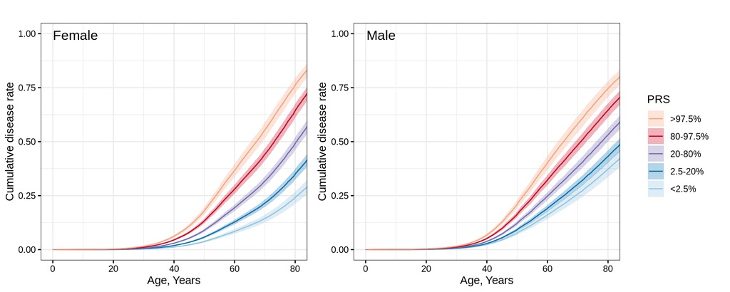

```r
#Female
p1 <- my_ggcoxplot(fit.sbp.f, df.sbp.f, "Female", legend="none")

#Male
p2 <- my_ggcoxplot(fit.sbp.m, df.sbp.m, "Male", legend="none")

lgnd <-  my_ggcoxplot(fit.sbp.f, df.sbp.f, "", legend="right") %>%
         get_legend()

splots <- grid.arrange(p1, p2, lgnd, nrow = 1, widths = c(3,3,1))
```

```r
ggsave(file = "cx_ht_prs_sex.png", plot = splots, height = 4, width = 10, dpi = 150)
#ggsave(file = "cx_ht_prs.pdf", plot = splots, height = 4, width = 10, dpi = 150)
ggsave(file = "cx_ht_prs_sex.eps", device = cairo_ps, plot = splots, height = 4, width = 10, dpi = 150)
```

## 2.5 Restricted mean survival times

Pairwise statistics between reference risk (20-80% quantile) and each other quantile is are calculated. For this purpose we need separate dataframe for each statistic of interest.

**Creating dataframes for each cases:**

```r
q <- c("<2.5%", "2.5-20%", "80-97.5%", ">97.5%" )
df.list.sbp.f  <-  lapply(q, my_extr_cats2, cat="SBP_CAT", df=df_f)
df.list.sbp.m  <-  lapply(q, my_extr_cats2, cat="SBP_CAT", df=df_m)
```

**rmst2 is runned for all cases**

Unadjusted analysis - with covariates R is slow and output of this package does not include mean ages for adjusted.

```r
#Unadjusted, this works:

rmst0.sbp.f <- lapply(df.list.sbp.f, function(x) rmst2(x$I9_HYPTENS_AGE, x$I9_HYPTENS, x$CAT, tau=95))
rmst0.sbp.m <- lapply(df.list.sbp.m, function(x) rmst2(x$I9_HYPTENS_AGE, x$I9_HYPTENS, x$CAT, tau=95))
```

**Results are extracted for the table**

SBP for females and males

```r
#Results extracted and collected to table

rmst.table <-
  my_rmst_coefs(rmst0.sbp.f) %>%
  bind_rows(my_rmst_coefs(rmst0.sbp.m)) %>%
  my_tidy_table("0", 1) %>%
  add_row(q="Female", est="", pval="", lower_mean=NA, upper_mean=NA, mean=NA,  .before = 1) %>%
  add_row(q="", est="", pval="", lower_mean=NA, upper_mean=NA, mean=NA,  .before = 7) %>%
  add_row(q="Male", est="", pval="", lower_mean=NA, upper_mean=NA, mean=NA, .before = 8)


#rmst.table divided to two and formatted for forestplot

rmst.means <- rmst.table %>%
  select(mean, lower_mean, upper_mean) %>%
  rename(lower = lower_mean, upper=upper_mean) %>%
  add_row(mean=NA, lower=NA, upper=NA, .before = 1)

rmst.text <- rmst.table %>%
 select(q, est, pval) %>%
  mutate(pval = sub("e(-\\d+)", "%*%10^{\\1}", pval, perl=T)) %>%     #to create proper exponents...
  add_row(q=NA, est="Difference, Years (95% CI)", pval="P-value", .before = 1)

#To create proper exponents... I need actual values as 'expression' and other lines as 'character'.
#list format is needed to accomodate different datatypes; parse can convert character unlike 'as.expression'
pvals <- lapply(rmst.text$pval, function(x) {ifelse(grepl("10",x), parse(text = x), x)})
rmst.text.list <- list(as.list(rmst.text$q), as.list(rmst.text$est), pvals)
```

**Forestplots**

```r
setEPS()
postscript(file = 'rmst_unadj_bysex.eps', width = 9, height = 4.5)

my_rmst_plot(rmst.text.list, rmst.means,
             clip=c(65,90), xticks = c(65, 70, 75,  80, 85), zero=65)
dev.off()
```

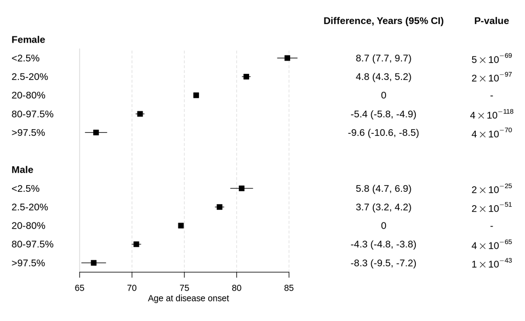

```r
my_rmst_plot(rmst.text.list, rmst.means,
             clip=c(65,90), xticks = c(65, 70, 75,  80, 85), zero=65)
```

**Test: Only time differences shown**

```r
#Let's test this too
rmst.diffs <-
  my_rmst_coefs(rmst0.sbp.f) %>%
  bind_rows(my_rmst_coefs(rmst0.sbp.m)) %>%
  select(est, lower, upper) %>%
  mutate_all(replace_na, 0) %>%
  add_row(est=NA, lower=NA, upper=NA, .before = 1) %>%
  add_row(est=NA, lower=NA, upper=NA, .before = 1) %>%
  add_row(est=NA, lower=NA, upper=NA, .before = 8) %>%
  add_row(est=NA, lower=NA, upper=NA, .before = 9) %>%
  rename(mean=est) %>%
  mutate_all(as.numeric)
```

And plot…

```r
setEPS()
postscript(file = 'rmst_diffs_unadj_bysex.eps', width = 9, height = 4.5)

my_rmst_plot(rmst.text.list, rmst.diffs,
             clip=c(-11, 10), xticks = c(-10, -5, 0, 5, 10), zero=0,
             xlab = "Age difference, years")

dev.off()
```

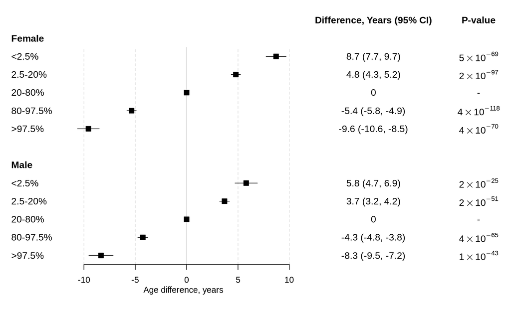

```r
my_rmst_plot(rmst.text.list, rmst.diffs,
             clip=c(-11, 10), xticks = c(-10, -5, 0, 5, 10), zero=0,
             xlab = "Age difference, years")
```